# Donor Profile: United Nations Central Emergency Response Fund (CERF)

## Focus Portfolio

UNHCR’s 2025 CERF portfolio exposes critical funding imbalances across six regions, with total donor contributions averaging $2.06 million yet ranging widely from $350,000 to $4.5 million per allocation. This volatility underscores strategic complications: regions with lower allocations risk undermining emergency response efficacy and resilience building. The data reveals a clear opportunity for donors to leverage targeted investments where average funding falls below $1.15 million—the 25th percentile—yielding an impact multiplier by stabilizing vulnerable operations. Prioritizing partnerships in underfunded regions aligns with donor imperatives for accountability and innovation, ensuring resources scale where humanitarian needs are most acute. Executives must immediately reposition funding strategies to close these quantifiable gaps, mitigating risks of operational disruptions while optimizing portfolio-wide impact. Mobilizing new and existing donor commitments around this compelling evidence offers a high-ROI path to strengthen UNHCR’s emergency responsiveness and build sustained resilience.

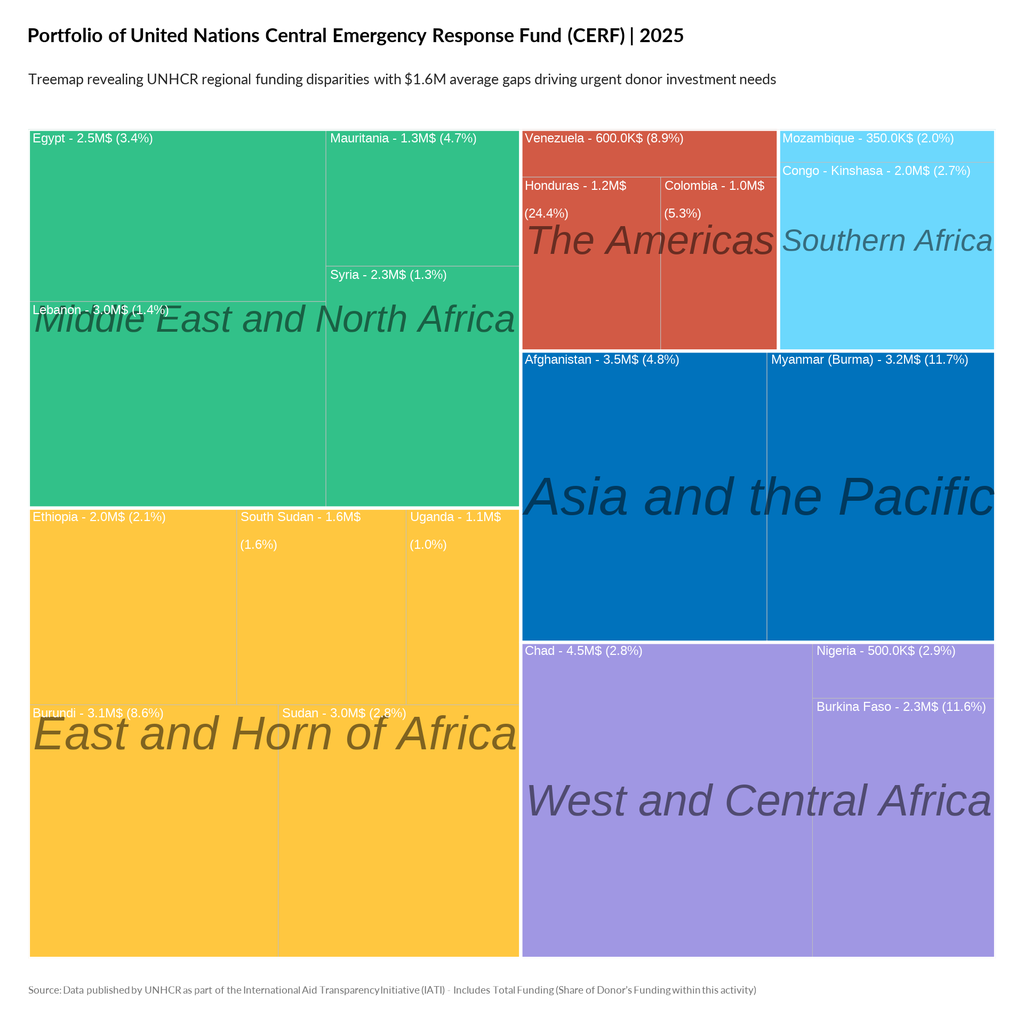

TRUE

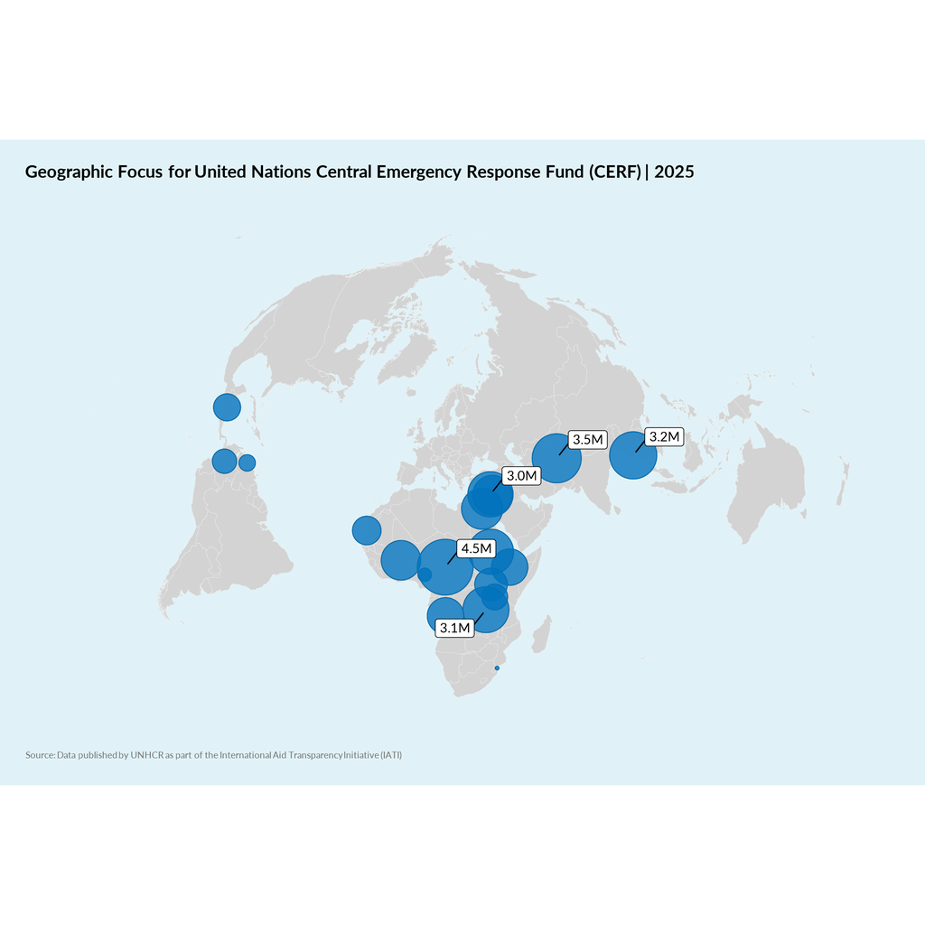

TRUE